# Perwalian Angkatan 2024 Semester 3 | S2 Statistika Terapan FMIPA Unpad

**S2 Statistika Terapan FMIPA Unpad**Pasca Sarjana Statistika · Universitas Padjadjaran

master.statistics.unpad.ac.id

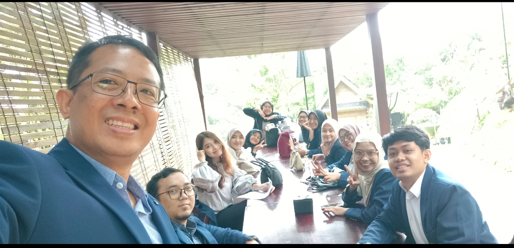

Berita Akademik · Perwalian Bersama

# Perwalian Angkatan 2024 Semester 3

Penguatan kesiapan tesis, strategi lulus tepat waktu, serta penjelasan tahapan Seminar Usulan Riset dan Sidang Akhir Magister.

Selasa, 5 Agustus 202509.00–12.00 WIBCafé D'Pakar, Dago, BandungPelaksanaan luring

[figure not shown]

Peserta**Mahasiswa Angkatan 2024**

Semester**Semester 3**

Waktu**5 Agustus 2025 · 09.00–12.00 WIB**

Fokus**Tesis dan kelulusan tepat waktu**

## Memasuki fase penting penyelesaian studi

Program Studi Magister Statistika Terapan FMIPA Universitas Padjadjaran menyelenggarakan perwalian bersama mahasiswa Angkatan 2024 Semester 3 pada **Selasa, 5 Agustus 2025**. Kegiatan berlangsung secara luring di **Café D'Pakar, Dago, Bandung**, mulai pukul **09.00 hingga 12.00 WIB**.

Perwalian dipimpin oleh Ketua Program Studi S2 Statistika Terapan, **I Gede Nyoman Mindra Jaya**. Forum ini dirancang untuk memastikan setiap mahasiswa memahami tahapan penyelesaian tesis, kewajiban akademik, serta strategi menyelesaikan studi secara tepat waktu.

**Pesan utama kegiatan:** Semester 3 merupakan fase konsolidasi. Mahasiswa perlu mengubah rencana tesis menjadi target kerja yang terukur, menjaga ritme bimbingan, menuntaskan setiap dokumen akademik tepat waktu, dan segera menyelesaikan tindak lanjut setelah seminar maupun sidang.

## Persiapan pelaksanaan tesis

Pada sesi utama dijelaskan bahwa kesiapan tesis tidak hanya bergantung pada kualitas topik, tetapi juga pada kejelasan pertanyaan penelitian, ketersediaan data, ketepatan metode, konsistensi bimbingan, dan kemampuan mengelola proses penelitian dari awal hingga penyusunan naskah akhir.

Mahasiswa diarahkan untuk memastikan keselarasan antara judul, tujuan, data, metode analisis, dan kontribusi penelitian. Setiap perkembangan penelitian perlu didokumentasikan agar proses konsultasi, evaluasi, serta persiapan seminar dan sidang dapat berlangsung lebih efisien.

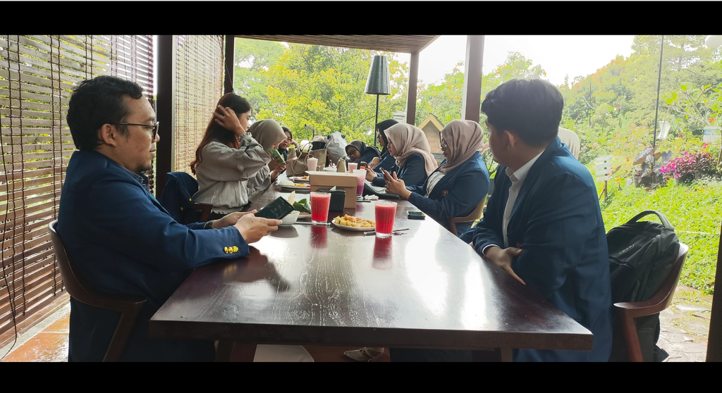

Suasana diskusi akademik dalam perwalian Angkatan 2024 Semester 3.

## Alur menuju SUR dan Sidang Akhir Magister

Perwalian membahas urutan kerja akademik yang perlu dipantau bersama. Jadwal rinci tetap mengikuti kalender akademik, kesiapan dokumen, persetujuan pembimbing, serta mekanisme penjadwalan program studi.

01

**Finalisasi topik dan rancangan penelitian**Memastikan fokus masalah, tujuan, data, metode, dan kontribusi tesis dirumuskan secara konsisten.

02

**Persiapan dan pendaftaran Seminar Usulan Riset**Melengkapi proposal, persetujuan pembimbing, dokumen administrasi, dan bahan presentasi.

03

**Pelaksanaan SUR dan tindak lanjut perbaikan**Mencatat masukan penguji, menyusun matriks revisi, dan menyelesaikan perbaikan secara terarah.

04

**Pelaksanaan penelitian dan penulisan tesis**Menjaga kualitas data, ketepatan analisis, dokumentasi kode, interpretasi hasil, dan konsistensi bimbingan.

05

**Persiapan Sidang Akhir Magister**Memastikan naskah tesis, hasil analisis, presentasi, dan seluruh persyaratan akademik telah lengkap.

06

**Sidang, revisi akhir, dan administrasi kelulusan**Menuntaskan revisi pascasidang, pengesahan naskah, unggah dokumen akhir, dan persyaratan kelulusan.

## Strategi lulus tepat waktu

Mahasiswa didorong untuk bekerja dengan target yang realistis namun tegas. Setiap tahap tesis perlu dipecah menjadi keluaran mingguan yang dapat dipantau. Hambatan metodologis, data, atau administrasi sebaiknya disampaikan sejak awal, bukan ketika tenggat sudah terlalu dekat.

**Tetapkan target mingguan**Pecah pekerjaan besar menjadi target kecil seperti subbab, pembersihan data, analisis, atau revisi.

**Jaga ritme bimbingan**Jadwalkan konsultasi secara konsisten dan kirimkan bahan terstruktur sebelum pertemuan.

**Dokumentasikan penelitian**Simpan data, kode, hasil analisis, versi naskah, dan catatan revisi secara rapi.

**Respons cepat terhadap masukan**Tindak lanjuti komentar pembimbing dan penguji dengan matriks revisi yang jelas.

**Siapkan administrasi lebih awal**Periksa persyaratan seminar dan sidang sebelum tenggat agar proses tidak tertunda.

**Jaga mutu dan integritas**Pastikan analisis dapat direproduksi, sumber dikutip benar, dan hasil dilaporkan jujur.

## Perwalian dalam suasana akademik yang hangat

Pemilihan lokasi di Café D'Pakar menghadirkan suasana yang lebih cair tanpa mengurangi substansi akademik. Mahasiswa dapat menyampaikan perkembangan tesis, hambatan yang dihadapi, serta kebutuhan dukungan secara lebih terbuka. Pertemuan ini sekaligus memperkuat komunikasi antara program studi dan mahasiswa pada fase akhir penyelesaian studi.

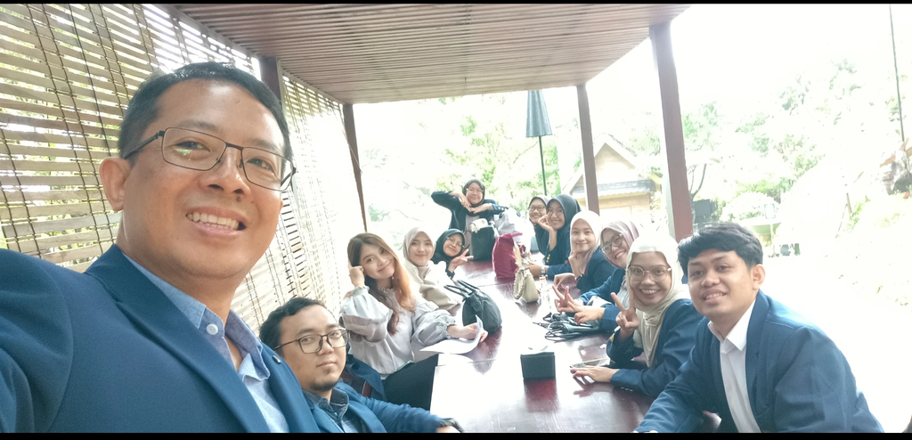

Foto bersama mahasiswa Angkatan 2024 dan Ketua Program Studi S2 Statistika Terapan.

Melalui perwalian ini, seluruh mahasiswa diharapkan memiliki peta jalan penyelesaian tesis yang lebih jelas, mampu menjaga konsistensi penelitian, serta menuntaskan Seminar Usulan Riset, Sidang Akhir Magister, dan seluruh kewajiban akademik secara bermutu dan tepat waktu.

### Pimpinan kegiatan

Ketua Program Studi**I Gede Nyoman Mindra Jaya**S2 Statistika Terapan FMIPA Unpad

### Mahasiswa yang hadir

- **S**Syahla Anisah
- **M**Muhamad Ramdhani
- **A**Agy Aswad Ilham
- **J**Jesicha Aulia Adam
- **M**Muhammad Restu Agam
- **N**Nisa Akbarilah Putri
- **A**Anindya Nitisari
- **L**Leivina Saliaputri
- **G**Gracia Joanne Crissan BR Hutabarat
- **A**Anggie Alnurin Prasetya
- **D**Disa Rahma Kirana
- **L**Luri Zahara

Total mahasiswa hadir: 12 orang

Dokumentasi kegiatan